# Galaxy formation, evolution, and cosmic structure

Research Cluster 4

Cluster 4 examines how galaxies form and change, and how they fit into the larger structure of the universe. Its communities connect processes within star-forming clouds to the growth of galaxies and the distribution of matter across cosmic distances. Observations of galaxies at different distances provide evidence from different periods in cosmic history, while numerical simulations help researchers investigate how the patterns they observe could have developed.

Star formation provides one connection across the cluster. Research on interstellar clouds examines how gas cools, gathers, and collapses to form stars. Work on gas and dust across galaxy populations asks how much material is available for further star formation. Studies of stellar populations then examine the accumulated result, estimating galaxies’ stellar masses and reconstructing their histories of star formation. Together, these communities address how galaxies build their stars, how stellar activity changes the surrounding gas, and why some galaxies continue forming stars while others become quiescent.

Galaxy growth also involves interactions, mergers, and activity around central black holes. Survey-based research compares how galaxies’ sizes, shapes, colours, and chemical composition vary with their mass and surroundings. The quasar community adds questions about accretion onto supermassive black holes and the radiation produced near them. Research on distant star-forming galaxies extends the account into the early universe, including how radiation escaping from galaxies changed the gas between them.

At a larger scale, the cosmology community uses the distribution and motion of galaxies, gravitational lensing, and simulations to investigate dark matter, dark energy, and the growth of cosmic structure. Galaxies serve both as objects whose development needs explaining and as evidence about the universe in which they formed. Research on the stellar halo adds another scale of inquiry, using stars around a galaxy’s main body to investigate its assembly history.

Measurement connects these substantive questions. Sky surveys, catalogues, photometry, and spectroscopy provide the evidence used to estimate distances and galaxy properties. Work on dust extinction and uncertainty examines how reliably those estimates can be made. A further community includes stellar pulsation alongside research on emission from gas, adding questions about the behaviour of individual stars and the interaction of radiation with matter.

Three forms of evidence below show what the keyword communities are about and how they relate to one another.

**Interactive keyword network.** Each point represents a keyword, and a line connects two keywords that appear together in one or more publications. The full network shows how keyword communities relate to one another. Select a community from the dropdown to see which terms group together and which connect to terms in other communities. Connections within a community show which subjects, methods, or concepts appear together. Connections across communities show where their vocabularies overlap.

**Community word clouds.** Each cloud shows the vocabulary of one community. Larger words have higher within-community PageRank. This measure reflects both the strength of a keyword’s connections and how well connected its neighbours are. Larger words therefore show which terms are most prominent in the community’s pattern of connections. Smaller words can give those terms context by identifying particular subjects, settings, or methods.

**Affiliated publications.** Each publication has a set of membership values, one for each community. A value of 1 means that all of the publication’s keyword-based membership is assigned to that community. When membership is distributed across communities, the values show how that affiliation is shared. For example, values of 0.7 and 0.3 indicate that the publication’s keywords align more strongly with the first community while also connecting it to the second. The publication lists show how the themes visible in the keyword network are represented in the institution’s research.

[interactive chart not shown]

## Community 1: Galaxy and star formation in the early universe

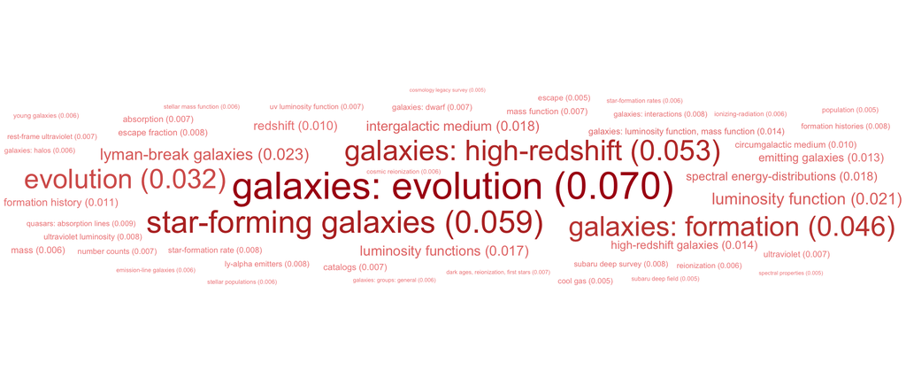

Community 1 of Cluster 4 examines how galaxies formed, built up their stars, and changed over cosmic time. “Galaxies: evolution” (0.070), “star-forming galaxies” (0.059), “galaxies: high-redshift” (0.053), and “galaxies: formation” (0.046) lead the within-community PageRank ranking. High-redshift galaxies provide observations of earlier periods in the universe’s history because their light has taken billions of years to reach us. Keywords such as “Lyman-break galaxies” and “Ly-alpha emitters” identify populations selected through features in their spectra, while deep surveys provide the observations used to find and compare them.

“Luminosity function,” “mass function,” and “star-formation rate” point to questions about how common galaxies of different brightnesses and masses are, and how rapidly they produce stars. These comparisons help researchers reconstruct how galaxy populations developed. A related strand examines the gas within and around galaxies. “Circumgalactic medium,” “intergalactic medium,” and “quasars: absorption lines” point to ways of studying that gas. “Escape fraction,” “ionizing radiation,” and “reionization” connect star-forming galaxies to questions about how radiation from early sources changed the state of gas throughout the universe.

The closest comparison is Cluster 3’s community on supermassive black holes and galaxy evolution. Both study galaxy populations, stellar mass, and star formation. Here, the highest-ranking terms give more emphasis to early galaxies and their contribution to cosmic history. There is also a connection to Cluster 1’s star formation research. That work examines how individual stars form, while this community asks how the accumulated formation of stars shapes galaxies over time.

## Community 2: Star formation

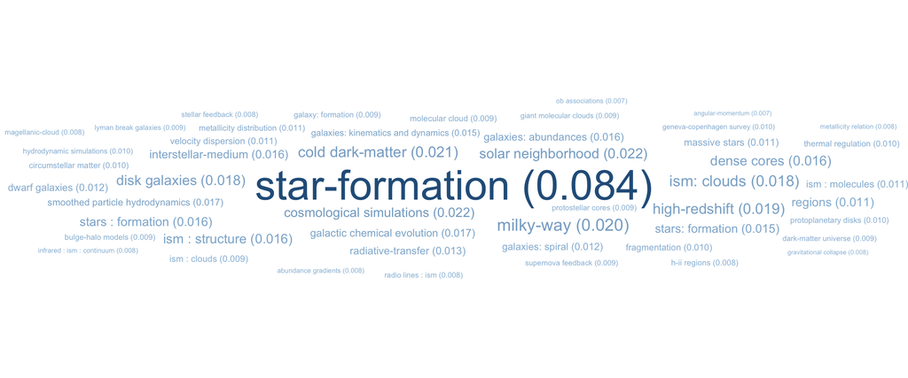

Community 2 of Cluster 4 examines how gas forms stars and how that process shapes galaxies. “Star formation” has the highest within-community PageRank (0.084), followed by “cosmological simulations” (0.022), “solar neighborhood” (0.022), “cold dark matter” (0.021), and “Milky Way” (0.020). These terms connect the study of star formation near the Sun to models of how galaxies develop within the wider universe.

One strand concerns the conditions within star-forming clouds. “Dense cores,” “gravitational collapse,” and “fragmentation” point to how gas collects and breaks into regions that can form stars. “Thermal regulation” and “radiative transfer” indicate an interest in how heating, cooling, and radiation affect that process. A second strand follows the consequences for galaxies. “Stellar feedback” and “supernova feedback” concern how stars return energy and material to their surroundings, affecting the gas available for further star formation. “Galactic chemical evolution,” “metallicity distribution,” and “abundance gradients” point to how successive generations of stars change the chemical composition of a galaxy. Numerical simulations connect these processes across scales.

The closest connection is to Community 1’s research on galaxy formation and evolution. Community 1 foregrounds observations of distant galaxy populations and their star formation histories. This community gives more attention to the physical processes that produce those patterns, combining observations of the Milky Way and nearby clouds with simulations. It also overlaps with Cluster 1’s stellar formation research and Cluster 3’s work on young-star outflows, placing those local processes within an account of how galaxies develop.

## Community 3: Large-sclae cosmic strcture and models

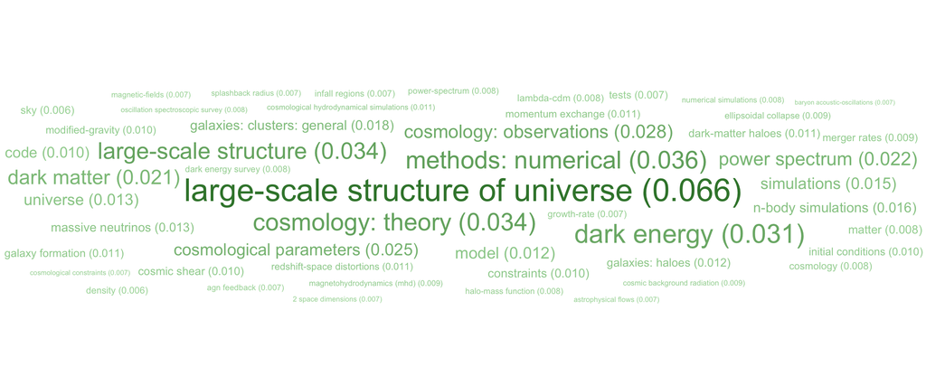

Community 3 of Cluster 4 examines how matter is distributed across the universe and what that distribution reveals about its composition and expansion. “Large-scale structure of universe” has the highest within-community PageRank (0.066), followed by “methods: numerical” (0.036), “cosmology: theory” (0.034), and another variant of “large-scale structure” (0.034). “Dark energy,” “dark matter,” and “cosmological parameters” give the community a focus on testing explanations of how cosmic structure developed. Massive neutrinos and modified gravity identify further ingredients or alternatives considered in those models.

Numerical simulations provide a way to follow how matter gathers under gravity into dark-matter haloes, galaxies, and galaxy clusters. Observational terms point to ways of comparing those predictions with the universe. The “power spectrum” describes how strongly matter clusters at different scales. Weak gravitational lensing measures distortions in the apparent shapes of distant galaxies caused by intervening matter, while “redshift-space distortions” provide information about galaxy motions and the growth of structure. Survey and cosmic background radiation keywords indicate additional evidence used to constrain cosmological models.

This community expands the scale of inquiry established by the first two communities. Community 1 examines how galaxy populations change over cosmic time, and Community 2 investigates how gas, star formation, and feedback shape individual galaxies. Here, galaxies and their surrounding dark-matter haloes also serve as evidence about the universe as a whole. Simulations connect all three communities, linking processes within galaxies to the larger structures in which galaxies form.

## Community 4: Galaxy surveys

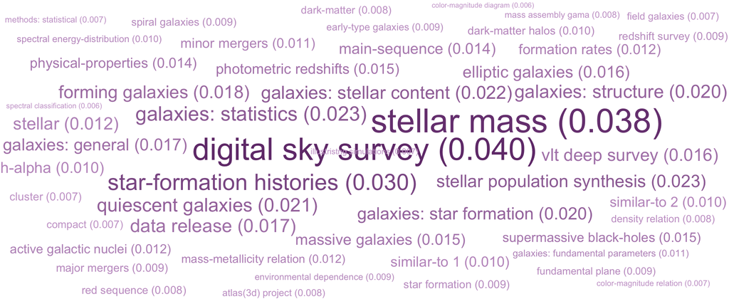

Community 4 of Cluster 4 examines how galaxies build their stellar populations and how their properties change over time. “Digital sky survey” (0.040), “stellar mass” (0.038), and “star-formation histories” (0.030) lead the within-community PageRank ranking. “Stellar population synthesis” points to modelling the combined light of stars of different ages and compositions to estimate a galaxy’s stellar content and reconstruct its history of star formation. Surveys provide the observations needed to compare these properties across galaxy populations.

The contrast between star-forming and quiescent galaxies—galaxies with little ongoing star formation—is a recurring focus. “Major mergers,” “minor mergers,” and “mass assembly” point to questions about how galaxies grow through interactions as well as by forming new stars. “Size evolution,” “morphological evolution,” and “galaxies: structure” extend the inquiry to changes in shape and internal arrangement. Relationships among mass, size, colour, and chemical composition provide ways to compare galaxies, while “environmental dependence,” “satellite galaxies,” and “cluster galaxies” introduce questions about how surroundings affect their development.

The closest connection is to Community 1’s work on galaxy populations across cosmic time. Community 1 gives more prominence to distant, early galaxies and their radiation. Here, survey-based comparisons of stellar content, structure, and star-formation histories provide the main focus. Community 2 supplies a physical counterpart through its study of gas, star formation, and feedback. Community 3 connects these galaxy populations to the distribution of matter on larger scales. This community helps link those scales by examining how individual galaxy properties vary across populations and environments.

## Community 5: Quasars

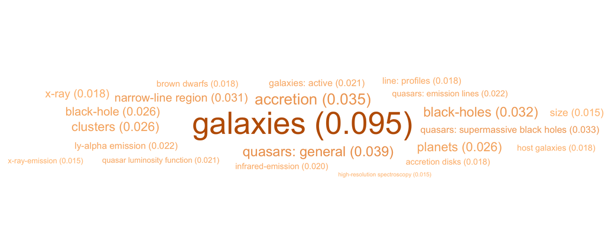

Community 5 of Cluster 4 focuses on quasars and active galaxies, where matter falling toward a supermassive black hole produces radiation. “Galaxies” has the highest within-community PageRank (0.095), followed by “quasars: general” (0.039), “accretion” (0.035), and “quasars: supermassive black holes” (0.033). Accretion disks, emission-line profiles, and high-resolution spectroscopy point to research on how radiation reveals the gas and its motion around these black holes. “Narrow-line region” identifies one region of emitting gas under study, while infrared and X-ray emission indicate observations across wavelengths.

“Host galaxies” and “quasar luminosity function” broaden the inquiry from individual sources to their galactic settings and to how common quasars of different brightnesses are. This connects the community to Community 4’s survey-based comparisons of galaxy populations. Community 4 foregrounds stellar content and star-formation histories. Here, activity associated with the central black hole receives more attention. The luminosity-function vocabulary also overlaps with Community 1’s work on distant galaxy populations.

The closest cross-cluster connection is to Cluster 3’s research on accretion and radiation in active galactic nuclei. This community brings those questions into Cluster 4’s broader account of galaxy formation and evolution. “Planets” and “brown dwarfs” also appear, indicating an additional strand beyond the quasar and galaxy research.

## Community 6: Interstellar gas

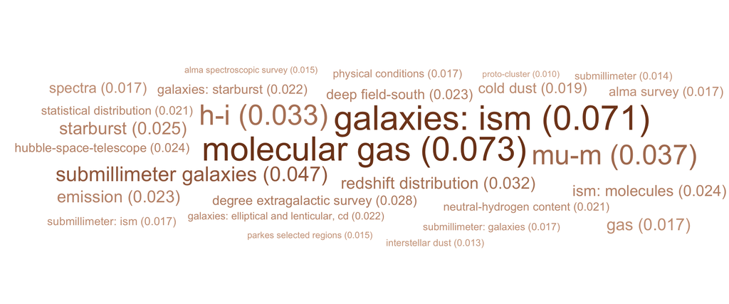

Community 6 of Cluster 4 examines the gas and dust within galaxies and their relationship to star formation. “Molecular gas” (0.073) and “galaxies: ISM” (0.071) lead the within-community PageRank ranking. ISM refers to the interstellar medium, the material between stars. “H I” and “neutral-hydrogen content” add an interest in atomic hydrogen, while “cold dust” and “interstellar dust” identify another component of that material. Together, these terms point to questions about how much gas galaxies contain, its physical conditions, and its availability for forming stars.

“Submillimeter galaxies,” “starburst,” and the ALMA survey terms give the community a focus on observations of gas and dust, including in galaxies undergoing intense star formation. “Redshift distribution” and “statistical distribution” indicate comparisons across galaxy populations and periods in cosmic history. The range of galaxy types named, including elliptical and lenticular galaxies, also suggests an interest in how gas content differs among galaxies.

The closest connection is to Community 2’s work on how interstellar gas forms stars and how stellar activity changes its surroundings. Here, observations of gas and dust across galaxy populations receive more emphasis. This also complements Community 4, which reconstructs galaxies’ stellar content and star-formation histories. The two communities examine related parts of galaxy development—one through the stars already formed, the other through the material available for further star formation. The distant, star-forming galaxies in Community 1 provide another point of overlap, with this community foregrounding their gas and dust.

## Community 7: Sky surveys

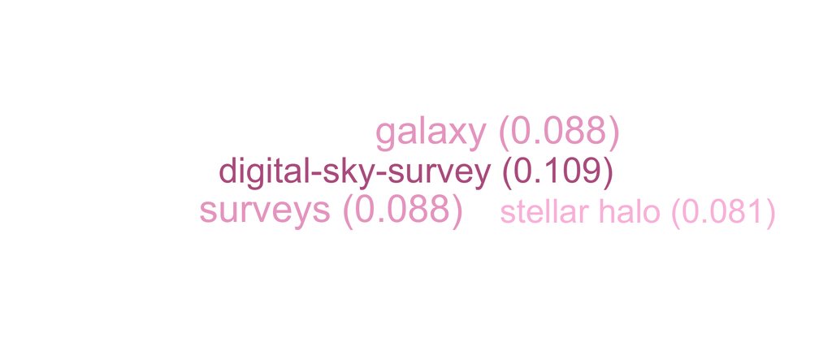

Community 7 of Cluster 4 points to survey-based research on the stellar halo, the extended population of stars surrounding a galaxy’s main body. “Digital sky survey” has the highest within-community PageRank (0.109), followed by “galaxy” and “surveys” (both 0.088), and “stellar halo” (0.081). These terms suggest an interest in mapping halo stars and using their distribution to investigate how a galaxy assembled.

The survey emphasis connects this community to Community 4’s comparisons of galaxy populations. Here, the named subject is a component within a galaxy, giving the cluster another scale at which to examine galaxy structure and history.

## Community 8: Stellar pulsation and emmision from cosmic gas

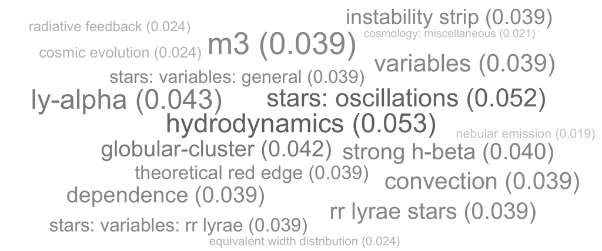

This community in Cluster 4 brings together research on stellar pulsation and on radiation associated with galaxy evolution. “Hydrodynamics” (0.053) and “stars: oscillations” (0.052) lead the within-community PageRank ranking. “RR Lyrae stars,” “convection,” and “instability strip” give the stellar strand a focus on why some stars pulsate and under what conditions those pulsations occur. The “theoretical red edge” concerns the cooler boundary of the region where pulsation is sustained. “Globular cluster” and “M3” provide a setting for studying these variable stars.

A second strand is visible in “Ly-alpha,” “nebular emission,” “radiative feedback,” and “cosmic evolution.” These terms point to research on radiation emitted by gas and how radiation affects its surroundings. “Equivalent width distribution” indicates comparisons of emission-line strength across a population of sources. This connects to Community 1’s work on early galaxies, where Ly-alpha emission and the passage of radiation through gas help researchers investigate galaxy development.

The stellar strand overlaps with Cluster 3’s community on stellar variability and oscillations. Within Cluster 4, it also shares Community 2’s interest in hydrodynamics and the interaction between radiation and gas. The grouping therefore adds work at the scale of individual stars alongside questions about radiation and change at galactic scales.

## Community 9: Galaxy photometry

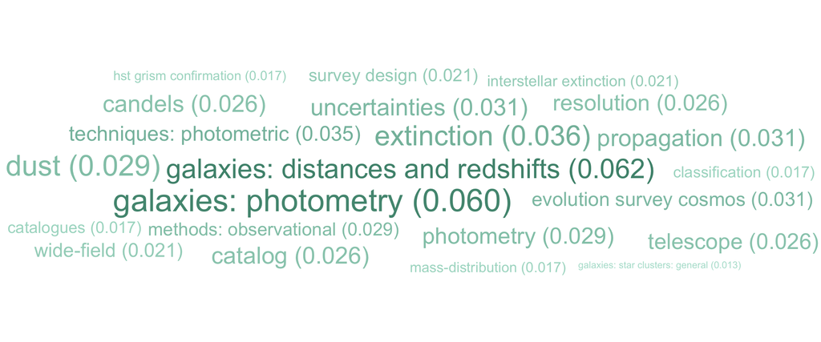

This community in Cluster 4 focuses on how astronomers measure galaxy brightness, estimate distances and redshifts, and account for uncertainty in those measurements. “Galaxies: distances and redshifts” (0.062) and “galaxies: photometry” (0.060) have the highest within-community PageRank. Photometry measures brightness through different filters, providing information used to estimate galaxy properties and distances. “Extinction,” “dust,” and “interstellar extinction” point to the effects of dust, which dims and reddens light and must be accounted for when interpreting observations. “Uncertainties” and “propagation” suggest attention to how measurement errors carry through into the quantities researchers derive.

“Cosmos,” “candels,” “wide-field,” and “survey design” place this work within observational programmes that collect measurements for many galaxies. Catalogues organize those measurements, while classification and spectroscopic confirmation help researchers identify sources and evaluate estimates. The community therefore includes the work of designing observations, constructing datasets, and assessing how reliably they represent galaxy populations.

The closest connection is to Community 4’s survey-based research on stellar mass and star-formation histories. Those interpretations depend on the brightness measurements, distance estimates, and dust corrections foregrounded here. The same connection extends to Community 1’s comparisons of distant galaxies and Community 6’s observations of gas and dust. This community gives more attention to how the observational evidence underlying those studies is produced and evaluated.

## Most cited publications by community

Select one of the communities above to populate the table. The table shows up to five publications per selected research community, arranged by highest Total Citation count within the research community under consideration. Under Membership vector the column headers indicate abbreviated research community labels. Each row sum totals 1.0. Values of 1 indicate maximal research community affiliation; distributed values indicate multithematic papers whose affiliation reaches into more than one research community (Aria et al. 2026; Aria and Cuccurullo 2026). TCpY = Total Citations per Year.

Community:

| Publication title | Year | TC | TCpY | Membership vector For | Membership vector interstellar gas, and galaxy development,Sta | Membership vector Lar | Membership vector stellar populaitons, and mass assembly, | Membership vector black-hole accretion, and host galaxies,Qua | Membership vector dust, and star formation,Int | Membership vector Sky | Membership vector Ste | Membership vector distances, and survey methods,Pho |
| --- | --- | --- | --- | --- | --- | --- | --- | --- | --- | --- | --- | --- |
| Great Optically Luminous Dropout Research using Subaru Hsc (Goldrush). I. Uv Luminosity Functions at z ∼ 4-7 Derived with the Half-Million Dropouts on the 100 Deg2 Sky | 2018 | 186 | 20.7 | 0.9 | 0.0 | 0.0 | 0.1 | 0.0 | 0.0 | 0.0 | 0.0 | 0.0 |
| Magicc Haloes: Confronting Simulations with Observations of the Circumgalactic Medium at Z=0 | 2012 | 124 | 8.3 | 0.5 | 0.0 | 0.0 | 0.0 | 0.2 | 0.2 | 0.0 | 0.1 | 0.0 |
| Ionizing Radiation from Z=4-10 Galaxies | 2010 | 124 | 7.3 | 0.5 | 0.4 | 0.1 | 0.0 | 0.0 | 0.0 | 0.0 | 0.0 | 0.0 |
| Lyα Radiative Transfer in Cosmological Simulations using Adaptive Mesh Refinement | 2009 | 93 | 5.2 | 0.7 | 0.0 | 0.0 | 0.1 | 0.1 | 0.1 | 0.0 | 0.0 | 0.0 |
| Differential Evolution of the Uv Luminosity Function of Lyman Break Galaxies from z ∼ 5 to 3 | 2007 | 75 | 3.8 | 0.9 | 0.0 | 0.0 | 0.1 | 0.0 | 0.0 | 0.0 | 0.0 | 0.0 |
| Metallicity Gradients in Disks Do Galaxies Form Inside-Out? | 2012 | 190 | 12.7 | 0.2 | 0.6 | 0.0 | 0.2 | 0.0 | 0.0 | 0.0 | 0.0 | 0.0 |
| Large Area Mapping at 850 Microns. Iii. Analysis of the Clump Distribution in the Orion b Molecular Cloud | 2001 | 169 | 6.5 | 0.0 | 0.9 | 0.0 | 0.1 | 0.0 | 0.0 | 0.0 | 0.0 | 0.0 |
| Thin Disc, Thick Disc and Halo in a Simulated Galaxy | 2012 | 168 | 11.2 | 0.2 | 0.7 | 0.0 | 0.0 | 0.0 | 0.0 | 0.1 | 0.0 | 0.0 |
| Hierarchical Formation of Bulgeless Galaxies - Ii. Redistribution of Angular Momentum via Galactic Fountains | 2012 | 166 | 11.1 | 0.3 | 0.7 | 0.0 | 0.0 | 0.0 | 0.0 | 0.0 | 0.0 | 0.0 |
| Intracluster Globular-Clusters | 1995 | 108 | 3.4 | 0.0 | 0.6 | 0.0 | 0.0 | 0.4 | 0.0 | 0.0 | 0.0 | 0.0 |
| The Vimos Public Extragalactic Redshift Survey (Vipers) the Growth of Structure at 0.5 &lt; z &lt; 1.2 from Redshift-Space Distortions in the Clustering of the Pdr-2 Final Sample | 2017 | 170 | 17.0 | 0.1 | 0.0 | 0.8 | 0.1 | 0.1 | 0.0 | 0.0 | 0.0 | 0.0 |
| The Vimos Public Extragalactic Redshift Survey (Vipers) Gravity Test from the Combination of Redshift-Space Distortions and Galaxy-Galaxy Lensing at 0.5 < z < 1.2 | 2017 | 82 | 8.2 | 0.1 | 0.0 | 0.8 | 0.1 | 0.0 | 0.0 | 0.0 | 0.0 | 0.0 |
| Euclid Preparation: Xxviii. Forecasts for Ten Different Higher-Order Weak Lensing Statistics | 2023 | 48 | 12.0 | 0.0 | 0.0 | 0.7 | 0.1 | 0.0 | 0.0 | 0.1 | 0.0 | 0.0 |
| The Vimos Public Extragalactic Redshift Survey (Vipers) Unbiased Clustering Estimate with Vipers Slit Assignment | 2018 | 42 | 4.7 | 0.3 | 0.0 | 0.5 | 0.2 | 0.0 | 0.0 | 0.0 | 0.0 | 0.0 |
| Nifty Galaxy Cluster Simulations - Iv. Quantifying the Influence of Baryons on Halo Properties | 2016 | 40 | 3.6 | 0.1 | 0.2 | 0.5 | 0.1 | 0.0 | 0.0 | 0.0 | 0.0 | 0.1 |
| The Next Generation Virgo Cluster Survey (Ngvs). I. Introduction to the Survey | 2012 | 366 | 24.4 | 0.1 | 0.0 | 0.0 | 0.6 | 0.0 | 0.0 | 0.0 | 0.0 | 0.3 |
| Hcosmos: a Dense Spectroscopic Survey of r ≤ 21.3 Galaxies in the Cosmos Field | 2018 | 56 | 6.2 | 0.1 | 0.0 | 0.1 | 0.7 | 0.0 | 0.0 | 0.0 | 0.0 | 0.1 |
| The Vimos Public Extragalactic Redshift Survey (Vipers) Downsizing of the Blue Cloud and the Influence of Galaxy Size on Mass Quenching over the Last Eight Billion Years | 2017 | 56 | 5.6 | 0.1 | 0.0 | 0.0 | 0.9 | 0.0 | 0.0 | 0.0 | 0.0 | 0.0 |
| Clear: The Ionization and Chemical-Enrichment Properties of Galaxies at 1.1 < z < 2.3 | 2022 | 46 | 9.2 | 0.2 | 0.0 | 0.0 | 0.7 | 0.0 | 0.0 | 0.0 | 0.2 | 0.0 |
| Morphology-Density Relation, Quenching, and Mergers in Carla Clusters and Protoclusters at 1.4 &lt; z &lt; 2.8 | 2023 | 39 | 9.8 | 0.2 | 0.0 | 0.1 | 0.6 | 0.1 | 0.0 | 0.0 | 0.0 | 0.0 |
| The Discovery of the First "Changing Look" Quasar: New Insights into the Physics and Phenomenology of Active Galactic Nuclei | 2015 | 401 | 33.4 | 0.0 | 0.0 | 0.0 | 0.1 | 0.9 | 0.0 | 0.0 | 0.0 | 0.0 |
| The Near-Infrared Imager and Slitless Spectrograph for the James Webb Space Telescope. Ii. Wide Field Slitless Spectroscopy | 2022 | 99 | 19.8 | 0.0 | 0.0 | 0.0 | 0.2 | 0.8 | 0.0 | 0.0 | 0.0 | 0.0 |
| The Extremes of Agn Variability | 2017 | 20 | 2.0 | 0.0 | 0.0 | 0.0 | 0.0 | 1.0 | 0.0 | 0.0 | 0.0 | 0.0 |
| The Collisional and Photoionized Plasma in the Polarized Nls1 Galaxy Mrk 1239 | 2023 | 8 | 2.0 | 0.0 | 0.0 | 0.0 | 0.0 | 0.8 | 0.2 | 0.0 | 0.0 | 0.0 |
| Euclid Preparation Xxxviii. Spectroscopy of Active Galactic Nuclei with Nisp | 2024 | 7 | 2.3 | 0.2 | 0.0 | 0.0 | 0.1 | 0.8 | 0.0 | 0.0 | 0.0 | 0.0 |
| The Cool Interstellar Medium in Elliptical Galaxies. Ii. Gas Content in the Volume-Limited Sample and Results from the Combined Elliptical and Lenticular Surveys | 2010 | 72 | 4.2 | 0.0 | 0.1 | 0.0 | 0.0 | 0.1 | 0.8 | 0.0 | 0.0 | 0.0 |
| The Cool Ism in so Galaxies. Ii. a Survey of Atomic Gas | 2006 | 55 | 2.6 | 0.2 | 0.2 | 0.0 | 0.0 | 0.0 | 0.6 | 0.0 | 0.0 | 0.0 |
| a Dense, Solar Metallicity Ism in the Z=4.2 Dusty Star-Forming Galaxy Spt 0418-47 | 2019 | 49 | 6.1 | 0.1 | 0.2 | 0.0 | 0.0 | 0.0 | 0.8 | 0.0 | 0.0 | 0.0 |
| Imaging the Molecular Interstellar Medium in a Gravitationally Lensed Star-Forming Galaxy at Z=5.7 | 2019 | 31 | 3.9 | 0.1 | 0.0 | 0.0 | 0.1 | 0.0 | 0.8 | 0.0 | 0.0 | 0.0 |
| Spatially Resolved Water Emission from Gravitationally Lensed Dusty Star-Forming Galaxies at z ∼ 3 | 2019 | 22 | 2.8 | 0.3 | 0.0 | 0.0 | 0.0 | 0.0 | 0.7 | 0.0 | 0.0 | 0.0 |
| The Canada-France Imaging Survey: First Results from the u-Band Component | 2017 | 88 | 8.8 | 0.1 | 0.2 | 0.0 | 0.0 | 0.0 | 0.0 | 0.7 | 0.0 | 0.0 |
| Properties of 42 Solar-Type Kepler Targets from the Asteroseismic Modeling Portal | 2014 | 129 | 9.9 | 0.0 | 0.0 | 0.4 | 0.0 | 0.0 | 0.0 | 0.0 | 0.6 | 0.0 |
| An Extremely Metal-Poor Star Complex in the Reionization Era: Approaching Population Iii Stars with Jwst | 2023 | 67 | 16.8 | 0.1 | 0.0 | 0.0 | 0.2 | 0.0 | 0.0 | 0.0 | 0.7 | 0.0 |
| Radial Stellar Pulsation and Three-Dimensional Convection. Iv. Full Amplitude Three-Dimensional Solutions | 2015 | 11 | 0.9 | 0.0 | 0.0 | 0.1 | 0.0 | 0.0 | 0.0 | 0.0 | 0.9 | 0.0 |
| Radial Stellar Pulsation and Three-Dimensional Convection. Ii. Two-Dimensional Convection in Full Amplitude Radial Pulsation | 2013 | 11 | 0.8 | 0.0 | 0.0 | 0.1 | 0.0 | 0.0 | 0.0 | 0.0 | 0.9 | 0.0 |
| The First Large Catalogue of Spectroscopic Redshifts in Webb's First Deep Field, Smacs J0723.3-7327 | 2023 | 40 | 10.0 | 0.0 | 0.0 | 0.1 | 0.2 | 0.2 | 0.0 | 0.0 | 0.0 | 0.6 |
| The Next Generation Virgo Cluster Survey. Xv. the Photometric Redshift Estimation for Background Sources | 2014 | 30 | 2.3 | 0.1 | 0.1 | 0.0 | 0.1 | 0.0 | 0.1 | 0.0 | 0.0 | 0.6 |
| Galactic Clusters with Associated Cepheid Variables - Vii. Berkeley 58 and Cg Cassiopeiae | 2008 | 19 | 1.0 | 0.0 | 0.2 | 0.0 | 0.3 | 0.0 | 0.0 | 0.0 | 0.0 | 0.5 |
| Intracluster Light in the Core of z ∼ 2 Galaxy Proto-Clusters | 2023 | 14 | 3.5 | 0.2 | 0.0 | 0.1 | 0.2 | 0.0 | 0.0 | 0.0 | 0.0 | 0.5 |
| Euclid Preparation Xliii. Measuring Detailed Galaxy Morphologies for Euclid with Machine Learning | 2024 | 11 | 3.7 | 0.1 | 0.0 | 0.0 | 0.1 | 0.0 | 0.0 | 0.0 | 0.0 | 0.7 |

## References

Aria, Massimo, and Corrado Cuccurullo. 2026. *Science Mapping Analysis: A Primer with Biblioshiny*. Mailand: McGraw-Hill Education.

Aria, Massimo, Luca D’Aniello, Michelangelo Misuraca, and Maria Spano. 2026. “Rethinking Thematic Evolution in Science Mapping:an Integrated Framework for Longitudinal Analysis.” *Journal of Informetrics* 20 (4): 101877. https://doi.org/10.1016/j.joi.2026.101877.